# Cv (1)

[output not shown]

**Prompts Used:**

1. "How do I preprocess and resize images for ResNet50?"
2. "I am getting a ValueError while computing AUC. How can I fix it?"
3. "Can you help me build a DNN model for multi-class image classification?"
4. "Why am I getting an IndexError while flattening my image dataset?"
5. "How do I plot an AUC-ROC curve for multi-class classification?"
6. "What metrics should I use to evaluate my ResNet50 model performance?"
7. "How do I import image label from json file?"

1.Importing All Libraries

```python
import os
import json
import numpy as np
import pandas as pd
import matplotlib.pyplot as plt
import seaborn as sns

from PIL import Image

# scikit-learn for preprocessing, evaluation and kNN
from sklearn.model_selection import train_test_split, GridSearchCV
from sklearn.preprocessing import LabelEncoder
from sklearn.metrics import confusion_matrix, classification_report, roc_auc_score
from sklearn.neighbors import KNeighborsClassifier
from sklearn.preprocessing import label_binarize
from tensorflow.keras.applications import ResNet50
from tensorflow.keras.models import Sequential
from tensorflow.keras.layers import Dense, Dropout, Flatten, GlobalAveragePooling2D
from tensorflow.keras.optimizers import Adam
from tensorflow.keras.applications.resnet50 import preprocess_input
from sklearn.metrics import roc_auc_score

from sklearn.metrics import (
    confusion_matrix, accuracy_score, classification_report, roc_auc_score,
    log_loss, matthews_corrcoef, cohen_kappa_score, hamming_loss,
    jaccard_score, balanced_accuracy_score
)

import tensorflow as tf
from tensorflow.keras.models import Sequential
from tensorflow.keras.layers import Conv2D, MaxPooling2D, Flatten, Dense, Dropout
from sklearn.metrics import confusion_matrix, roc_auc_score, classification_report
```

2.Loading Dataset and Checking Paths

```python
json_path = "photos.json"
image_dir = r"E:\YelpPhotos\photos"  # Folder with .jpg files

# Load the JSON file
df = pd.read_json(json_path, lines=True)

# Create full image paths
df['image_path'] = df['photo_id'].apply(lambda x: os.path.join(image_dir, f"{x}.jpg"))

# Check if files exist
df['exists'] = df['image_path'].apply(os.path.exists)
missing_files = df[~df['exists']]
if not missing_files.empty:
    print("\n⚠️ Warning: Some image files are missing! Here are the first 5 missing files:")
    display(missing_files[['photo_id', 'image_path']].head())
else:
    print("\n✅ All image paths are valid!")


df.drop(columns=['exists'], inplace=True)

print("\nFirst 5 valid image paths:")
display(df[['photo_id', 'image_path']].head())
```

```
✅ All image paths are valid!

First 5 valid image paths:
```

|  | photo_id | image_path |
| --- | --- | --- |
| 0 | zsvj7vloL4L5jhYyPIuVwg | E:\YelpPhotos\photos\zsvj7vloL4L5jhYyPIuVwg.jpg |
| 1 | HCUdRJHHm_e0OCTlZetGLg | E:\YelpPhotos\photos\HCUdRJHHm_e0OCTlZetGLg.jpg |
| 2 | vkr8T0scuJmGVvN2HJelEA | E:\YelpPhotos\photos\vkr8T0scuJmGVvN2HJelEA.jpg |
| 3 | pve7D6NUrafHW3EAORubyw | E:\YelpPhotos\photos\pve7D6NUrafHW3EAORubyw.jpg |
| 4 | H52Er-uBg6rNrHcReWTD2w | E:\YelpPhotos\photos\H52Er-uBg6rNrHcReWTD2w.jpg |

3.Took 10K Samples of image to work with.

```python
SAMPLE_SIZE = 10000
df_small = df.head(SAMPLE_SIZE).copy()

print(f"Using {len(df_small)} images for this first step.")
```

```
Using 10000 images for this first step.
```

4.This function loads an image, converts it to RGB, resizes it to 64×64 pixels, and returns it as a NumPy array for further processing; if an error occurs, it returns None.

```python
IMG_SIZE = (64, 64)

def preprocess_image(image_path):
    try:
        img = Image.open(image_path).convert('RGB')
        img = img.resize(IMG_SIZE)
        return np.array(img)
    except Exception as e:
        return None
```

5.This code loads images and labels from df_small, converts them into NumPy arrays X (images) and y (labels), and prints their shapes.

```python
X_list = []
y_list = []

for idx, row in df_small.iterrows():
    img_array = preprocess_image(row["image_path"])
    if img_array is not None:
        X_list.append(img_array)
        y_list.append(row["label"])

X = np.array(X_list, dtype='float32')
y = np.array(y_list)

print("Shape of X:", X.shape)
print("Shape of y:", y.shape)
```

```
Shape of X: (9998, 64, 64, 3)
Shape of y: (9998,)
```

6.This code splits the data into training (80%) and testing (20%) sets and prints their shapes.

```python
from sklearn.model_selection import train_test_split

X_train, X_test, y_train, y_test = train_test_split(
    X, y,
    test_size=0.2,
    random_state=42
)

print("Train set:", X_train.shape, y_train.shape)
print("Test set:", X_test.shape, y_test.shape)
```

```
Train set: (7998, 64, 64, 3) (7998,)
Test set: (2000, 64, 64, 3) (2000,)
```

7.This code normalizes pixel values of the images in X_train and X_test to the range [0, 1] for better model performance and confirms normalization with a print statement.

```python
# Normalize pixel values to [0, 1]
X_train = X_train / 255.0
X_test = X_test / 255.0

print("Data normalized.")
```

```
Data normalized.
```

8.This code flattens the images from 3D (height, width, channels) to 2D arrays for DNN input and prints the new shapes of X_train_flat and X_test_flat.

```python
# Flatten images
X_train_flat = X_train.reshape(X_train.shape[0], -1)
X_test_flat = X_test.reshape(X_test.shape[0], -1)

print("X_train_flat shape:", X_train_flat.shape)
print("X_test_flat shape:", X_test_flat.shape)
```

```
X_train_flat shape: (7998, 12288)
X_test_flat shape: (2000, 12288)
```

```python
print(f"Number of training samples: {X_train.shape[0]}")
```

```
Number of training samples: 7998
```

```python
print("y_train shape:", y_train.shape)
print("Unique labels:", np.unique(y_train))
```

```
y_train shape: (7998,)
Unique labels: ['drink' 'food' 'inside' 'menu' 'outside']
```

9.This code converts string labels to integer labels using LabelEncoder, applies the encoding to both training and testing labels, and displays the mapping of original labels to their corresponding integers.

```python
from sklearn.preprocessing import LabelEncoder

# Encode string labels to integers
label_encoder = LabelEncoder()
y_train_encoded = label_encoder.fit_transform(y_train)
y_test_encoded = label_encoder.transform(y_test)

# Check the mapping
label_mapping = dict(zip(label_encoder.classes_, label_encoder.transform(label_encoder.classes_)))
print("Label Mapping:", label_mapping)
```

```
Label Mapping: {np.str_('drink'): np.int64(0), np.str_('food'): np.int64(1), np.str_('inside'): np.int64(2), np.str_('menu'): np.int64(3), np.str_('outside'): np.int64(4)}
```

10.This code **builds a Deep Neural Network (DNN)** with multiple dense and dropout layers for multi-class classification, **compiles the model** using the Adam optimizer and sparse categorical cross-entropy loss, and **displays the model architecture summary**.

```python
# Input dimension (flattened image size)
input_dim = X_train_flat.shape[1]
num_classes = len(np.unique(y_train_encoded))

# Build the DNN
model = Sequential([
    Dense(512, activation='relu', input_shape=(input_dim,)),
    Dropout(0.5),
    Dense(256, activation='relu'),
    Dropout(0.3),
    Dense(128, activation='relu'),
    Dropout(0.2),
    Dense(num_classes, activation='softmax')  # Softmax for multi-class classification
])


model.compile(
    optimizer='adam',
    loss='sparse_categorical_crossentropy',
    metrics=['accuracy']
)

# Model summary
model.summary()
```

```
Model: "sequential"
```

```
┏━━━━━━━━━━━━━━━━━━━━━━━━━━━━━━━━━┳━━━━━━━━━━━━━━━━━━━━━━━━┳━━━━━━━━━━━━━━━┓
┃ Layer (type)                    ┃ Output Shape           ┃       Param # ┃
┡━━━━━━━━━━━━━━━━━━━━━━━━━━━━━━━━━╇━━━━━━━━━━━━━━━━━━━━━━━━╇━━━━━━━━━━━━━━━┩
│ dense (Dense)                   │ (None, 512)            │     6,291,968 │
├─────────────────────────────────┼────────────────────────┼───────────────┤
│ dropout (Dropout)               │ (None, 512)            │             0 │
├─────────────────────────────────┼────────────────────────┼───────────────┤
│ dense_1 (Dense)                 │ (None, 256)            │       131,328 │
├─────────────────────────────────┼────────────────────────┼───────────────┤
│ dropout_1 (Dropout)             │ (None, 256)            │             0 │
├─────────────────────────────────┼────────────────────────┼───────────────┤
│ dense_2 (Dense)                 │ (None, 128)            │        32,896 │
├─────────────────────────────────┼────────────────────────┼───────────────┤
│ dropout_2 (Dropout)             │ (None, 128)            │             0 │
├─────────────────────────────────┼────────────────────────┼───────────────┤
│ dense_3 (Dense)                 │ (None, 5)              │           645 │
└─────────────────────────────────┴────────────────────────┴───────────────┘
```

```
 Total params: 6,456,837 (24.63 MB)
```

```
 Trainable params: 6,456,837 (24.63 MB)
```

```
 Non-trainable params: 0 (0.00 B)
```

```python
history = model.fit(
    X_train_flat,
    y_train_encoded,     # Using integer-encoded labels
    epochs=10,
    batch_size=64,
    validation_split=0.2,
    verbose=2
)
```

```
100/100 - 6s - 60ms/step - accuracy: 0.4870 - loss: 1.7285 - val_accuracy: 0.5612 - val_loss: 1.0674
100/100 - 5s - 49ms/step - accuracy: 0.5614 - loss: 1.1011 - val_accuracy: 0.6431 - val_loss: 1.0340
100/100 - 5s - 46ms/step - accuracy: 0.5686 - loss: 1.0753 - val_accuracy: 0.6644 - val_loss: 1.0411
100/100 - 5s - 45ms/step - accuracy: 0.5791 - loss: 1.0422 - val_accuracy: 0.6656 - val_loss: 1.0916
100/100 - 5s - 47ms/step - accuracy: 0.5717 - loss: 1.0537 - val_accuracy: 0.6706 - val_loss: 1.0220
100/100 - 5s - 46ms/step - accuracy: 0.5866 - loss: 1.0204 - val_accuracy: 0.6575 - val_loss: 1.0363
100/100 - 5s - 45ms/step - accuracy: 0.5941 - loss: 1.0164 - val_accuracy: 0.6006 - val_loss: 1.0942
100/100 - 5s - 45ms/step - accuracy: 0.6155 - loss: 0.9949 - val_accuracy: 0.5050 - val_loss: 1.1369
100/100 - 5s - 46ms/step - accuracy: 0.6363 - loss: 0.9660 - val_accuracy: 0.6463 - val_loss: 1.0098
100/100 - 5s - 48ms/step - accuracy: 0.6274 - loss: 0.9685 - val_accuracy: 0.5981 - val_loss: 1.0696
```

```python
# Evaluate on the training set
train_loss, train_acc = model.evaluate(X_train_flat, y_train_encoded, verbose=0)

# Evaluate on the test set
test_loss, test_acc = model.evaluate(X_test_flat, y_test_encoded, verbose=0)

# Print the results
print(f"✅ Training Accuracy: {train_acc:.4f}")
print(f"✅ Test Accuracy: {test_acc:.4f}")
```

```
✅ Training Accuracy: 0.6064
✅ Test Accuracy: 0.5995
```

```python
# Predict probabilities
y_probs = model.predict(X_test_flat)  # Shape: (num_samples, num_classes)

# Get predicted class indices
y_pred_classes = np.argmax(y_probs, axis=1)

# Convert predicted indices back to original labels
y_pred_labels = label_encoder.inverse_transform(y_pred_classes)

# Check sample predictions
print("Sample Predictions:", y_pred_labels[:5])
```

```
63/63 ━━━━━━━━━━━━━━━━━━━━ 0s 5ms/step
Sample Predictions: ['inside' 'food' 'inside' 'inside' 'inside']
```

[figure not shown]

```python
# Select the first test image
sample_index =18
sample_image = X_test[sample_index]
sample_label = y_pred_labels[sample_index]

# Display the image with the predicted label
plt.figure(figsize=(4, 4))
plt.imshow(sample_image)
plt.title(f"Predicted: {sample_label}", fontsize=14)
plt.axis('off')
plt.show()
```

```
63/63 ━━━━━━━━━━━━━━━━━━━━ 0s 3ms/step
```

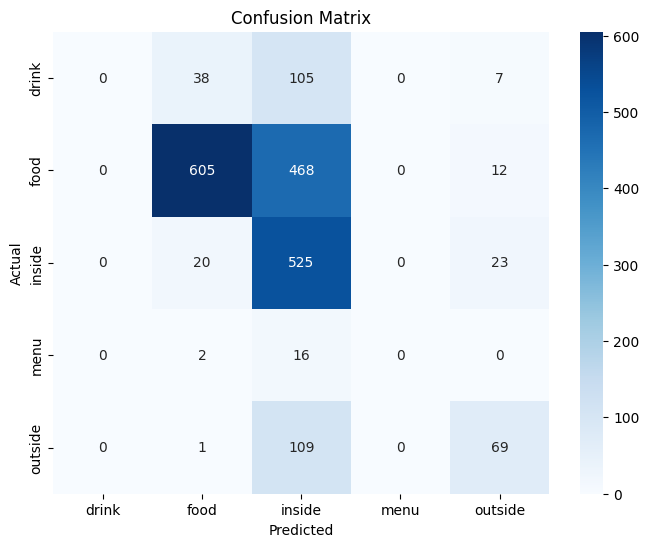

```python
from sklearn.metrics import (
    confusion_matrix, accuracy_score, classification_report,
    precision_score, recall_score, f1_score, roc_auc_score
)
import matplotlib.pyplot as plt
import seaborn as sns
import numpy as np

# Predict probabilities for each class
y_probs = model.predict(X_test_flat)  # Output: (num_samples, num_classes)

# Get predicted class indices
y_pred_classes = np.argmax(y_probs, axis=1)

# Generate Confusion Matrix
cm = confusion_matrix(y_test_encoded, y_pred_classes)

# Plot Confusion Matrix
plt.figure(figsize=(8, 6))
sns.heatmap(cm, annot=True, fmt='d', cmap='Blues',
            xticklabels=label_encoder.classes_,
            yticklabels=label_encoder.classes_)
plt.xlabel('Predicted')
plt.ylabel('Actual')
plt.title('Confusion Matrix')
plt.show()
```

```python
# Accuracy
accuracy = accuracy_score(y_test_encoded, y_pred_classes)

# Precision, Recall, F1-Score (Macro Average)
precision = precision_score(y_test_encoded, y_pred_classes, average='macro')
recall = recall_score(y_test_encoded, y_pred_classes, average='macro')
f1 = f1_score(y_test_encoded, y_pred_classes, average='macro')

# AUC Score (for Multi-class Classification)
try:
    auc = roc_auc_score(y_test_encoded, y_probs, multi_class='ovr', average='macro')
except ValueError:
    auc = "N/A"

# Display Metrics
print(f" Accuracy: {accuracy:.4f}")
print(f" Precision (Macro Avg): {precision:.4f}")
print(f" Recall (Macro Avg): {recall:.4f}")
print(f" F1-Score (Macro Avg): {f1:.4f}")
print(f" AUC (Macro Avg): {auc if auc != 'N/A' else 'N/A'}")
```

```
 Accuracy: 0.5995
 Precision (Macro Avg): 0.3919
 Recall (Macro Avg): 0.3735
 F1-Score (Macro Avg): 0.3506
 AUC (Macro Avg): 0.7102564748713307
```

```
 Macro-Averaged AUC: 0.7103
```

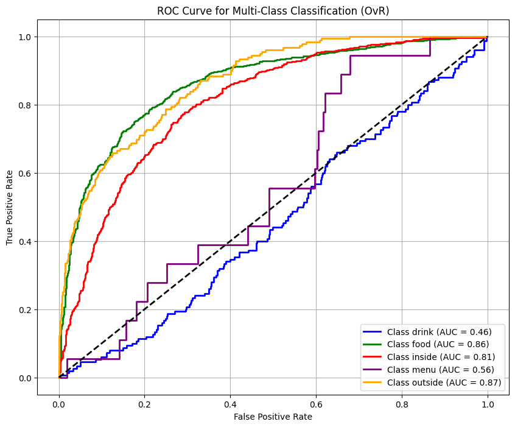

```python
from itertools import cycle


# AUC for multi-class (one-vs-rest)
try:
    auc_score = roc_auc_score(
        y_test_encoded,
        y_probs,
        average='macro',
        multi_class='ovr'
    )
    print(f" Macro-Averaged AUC: {auc_score:.4f}")
except ValueError as e:
    print(f" Could not compute AUC: {e}")


# Binarize the output labels for multi-class ROC
from sklearn.preprocessing import label_binarize

# Binarize the labels (required for ROC curve)
y_test_binarized = label_binarize(y_test_encoded, classes=np.unique(y_test_encoded))
n_classes = y_test_binarized.shape[1]

# Colors for different classes
colors = cycle(['blue', 'green', 'red', 'purple', 'orange'])

# Plot ROC curve for each class
plt.figure(figsize=(10, 8))

for i, color in zip(range(n_classes), colors):
    fpr, tpr, _ = roc_curve(y_test_binarized[:, i], y_probs[:, i])
    auc_class = roc_auc_score(y_test_binarized[:, i], y_probs[:, i])
    plt.plot(fpr, tpr, color=color, lw=2,
             label=f"Class {label_encoder.classes_[i]} (AUC = {auc_class:.2f})")

# Plot random chance line
plt.plot([0, 1], [0, 1], 'k--', lw=2)

# Plot formatting
plt.xlabel('False Positive Rate')
plt.ylabel('True Positive Rate')
plt.title('ROC Curve for Multi-Class Classification (OvR)')
plt.legend(loc='lower right')
plt.grid(True)
plt.show()
```

```python
from sklearn.metrics import classification_report

# Generate classification report
report = classification_report(y_test_encoded, y_pred_classes, target_names=label_encoder.classes_)
print("Classification Report:\n")
print(report)
```

```
Classification Report:

              precision    recall  f1-score   support

       drink       0.00      0.00      0.00       150
        food       0.91      0.56      0.69      1085
      inside       0.43      0.92      0.59       568
        menu       0.00      0.00      0.00        18
     outside       0.62      0.39      0.48       179

    accuracy                           0.60      2000
   macro avg       0.39      0.37      0.35      2000
weighted avg       0.67      0.60      0.58      2000
```

Below code resizes images to 224×224 (required for ResNet50), converts them to uint8, applies ResNet-specific preprocessing, and prepares X_train_resized and X_test_resized for model training.

```python
from tensorflow.keras.applications.resnet50 import preprocess_input

# ResNet50 expects images of size 224x224
IMG_SIZE_RESNET = (224, 224)

def resize_images(images):
    # Resize and convert images to uint8
    resized_images = np.array([
        np.array(Image.fromarray((img * 255).astype('uint8')).resize(IMG_SIZE_RESNET))
        for img in images
    ])

    # Apply ResNet-specific preprocessing
    return preprocess_input(resized_images)

# Resize and preprocess the training and testing data
X_train_resized = resize_images(X_train)
X_test_resized = resize_images(X_test)

print("✅ Images resized and preprocessed for ResNet.")
```

```
✅ Images resized and preprocessed for ResNet.
```

Below code loads a pre-trained ResNet50 model, freezes its layers, adds custom dense layers for multi-class classification, compiles the model with the Adam optimizer, and displays the model architecture summary.

```python
# Load the pre-trained ResNet50 model
base_model = ResNet50(weights='imagenet', include_top=False, input_shape=(224, 224, 3))

# Freeze the base model to prevent training
base_model.trainable = False

# Build the custom classification model
model_resnet = Sequential([
    base_model,
    GlobalAveragePooling2D(),   # Reduces the feature maps to a vector
    Dropout(0.5),
    Dense(256, activation='relu'),
    Dropout(0.3),
    Dense(num_classes, activation='softmax')  # For multi-class classification
])

# Compile the model
model_resnet.compile(
    optimizer=Adam(learning_rate=0.0001),  # Lower learning rate for fine-tuning
    loss='sparse_categorical_crossentropy',  # Integer-encoded labels
    metrics=['accuracy']
)

# Model summary
model_resnet.summary()
```

```
Downloading data from https://storage.googleapis.com/tensorflow/keras-applications/resnet/resnet50_weights_tf_dim_ordering_tf_kernels_notop.h5
94765736/94765736 ━━━━━━━━━━━━━━━━━━━━ 289s 3us/step
```

```
Model: "sequential_1"
```

```
┏━━━━━━━━━━━━━━━━━━━━━━━━━━━━━━━━━┳━━━━━━━━━━━━━━━━━━━━━━━━┳━━━━━━━━━━━━━━━┓
┃ Layer (type)                    ┃ Output Shape           ┃       Param # ┃
┡━━━━━━━━━━━━━━━━━━━━━━━━━━━━━━━━━╇━━━━━━━━━━━━━━━━━━━━━━━━╇━━━━━━━━━━━━━━━┩
│ resnet50 (Functional)           │ (None, 7, 7, 2048)     │    23,587,712 │
├─────────────────────────────────┼────────────────────────┼───────────────┤
│ global_average_pooling2d        │ (None, 2048)           │             0 │
│ (GlobalAveragePooling2D)        │                        │               │
├─────────────────────────────────┼────────────────────────┼───────────────┤
│ dropout_3 (Dropout)             │ (None, 2048)           │             0 │
├─────────────────────────────────┼────────────────────────┼───────────────┤
│ dense_4 (Dense)                 │ (None, 256)            │       524,544 │
├─────────────────────────────────┼────────────────────────┼───────────────┤
│ dropout_4 (Dropout)             │ (None, 256)            │             0 │
├─────────────────────────────────┼────────────────────────┼───────────────┤
│ dense_5 (Dense)                 │ (None, 5)              │         1,285 │
└─────────────────────────────────┴────────────────────────┴───────────────┘
```

```
 Total params: 24,113,541 (91.99 MB)
```

```
 Trainable params: 525,829 (2.01 MB)
```

```
 Non-trainable params: 23,587,712 (89.98 MB)
```

```python
# Train the model
history_resnet = model_resnet.fit(
    X_train_resized,
    y_train_encoded,
    epochs=10,             # Adjust based on performance
    batch_size=32,         # Use smaller batch size if memory is limited
    validation_split=0.2,  # 20% of training data for validation
    verbose=2
)
```

```
200/200 - 282s - 1s/step - accuracy: 0.7777 - loss: 0.6725 - val_accuracy: 0.9156 - val_loss: 0.2771
200/200 - 316s - 2s/step - accuracy: 0.8775 - loss: 0.3632 - val_accuracy: 0.9269 - val_loss: 0.2320
200/200 - 260s - 1s/step - accuracy: 0.8895 - loss: 0.3121 - val_accuracy: 0.9331 - val_loss: 0.2112
200/200 - 243s - 1s/step - accuracy: 0.9079 - loss: 0.2756 - val_accuracy: 0.9331 - val_loss: 0.2117
200/200 - 251s - 1s/step - accuracy: 0.9134 - loss: 0.2609 - val_accuracy: 0.9344 - val_loss: 0.2029
200/200 - 228s - 1s/step - accuracy: 0.9198 - loss: 0.2377 - val_accuracy: 0.9325 - val_loss: 0.1955
200/200 - 225s - 1s/step - accuracy: 0.9203 - loss: 0.2303 - val_accuracy: 0.9356 - val_loss: 0.1938
200/200 - 227s - 1s/step - accuracy: 0.9261 - loss: 0.2147 - val_accuracy: 0.9337 - val_loss: 0.1865
200/200 - 2621s - 13s/step - accuracy: 0.9203 - loss: 0.2161 - val_accuracy: 0.9350 - val_loss: 0.1899
200/200 - 225s - 1s/step - accuracy: 0.9264 - loss: 0.2008 - val_accuracy: 0.9356 - val_loss: 0.1896
```

```python
# Evaluate on the test set
test_loss, test_acc = model_resnet.evaluate(X_test_resized, y_test_encoded, verbose=0)
print(f" Test Accuracy (ResNet50): {test_acc:.4f}")
```

```
 Test Accuracy (ResNet50): 0.9360
```

```python
# Predict probabilities for each class
y_probs_resnet = model_resnet.predict(X_test_resized)

# Convert probabilities to predicted class indices
y_pred_classes_resnet = np.argmax(y_probs_resnet, axis=1)

# Convert class indices back to original labels
y_pred_labels_resnet = label_encoder.inverse_transform(y_pred_classes_resnet)

# Display sample predictions
print("Sample Predictions:", y_pred_labels_resnet[:5])
```

```
63/63 ━━━━━━━━━━━━━━━━━━━━ 60s 930ms/step
Sample Predictions: ['inside' 'food' 'inside' 'inside' 'food']
```

```python
# Function to preprocess the image
def preprocess_image_for_resnet(image_path):
    IMG_SIZE_RESNET = (224, 224)
    try:
        img = Image.open(image_path).convert('RGB')
        img = img.resize(IMG_SIZE_RESNET)
        img_array = np.array(img)
        img_array = preprocess_input(img_array)  # ResNet50 preprocessing
        return img_array
    except Exception as e:
        print(f"❌ Error loading image: {e}")
        return None

# Function to predict and display both predicted and actual labels
def predict_image(photo_id):
    # Construct the image path
    image_path = os.path.join(image_dir, f"{photo_id}.jpg")

    # Preprocess the image
    image_array = preprocess_image_for_resnet(image_path)

    if image_array is not None:
        # Add batch dimension for prediction
        image_input = np.expand_dims(image_array, axis=0)

        # Predict probabilities and get the predicted class
        predicted_probabilities = model_resnet.predict(image_input)
        predicted_class = np.argmax(predicted_probabilities)
        predicted_label = label_encoder.inverse_transform([predicted_class])[0]

        # Retrieve the actual label from the DataFrame (if exists)
        actual_label = "Unknown"  # Default value
        if photo_id in df['photo_id'].values:
            actual_label = df.loc[df['photo_id'] == photo_id, 'label'].values[0]

        # Display the image with both predicted and actual labels
        plt.figure(figsize=(4, 4))
        plt.imshow(Image.open(image_path))
        plt.title(f"Predicted: {predicted_label}\nActual: {actual_label}", fontsize=14)
        plt.axis('off')
        plt.show()

        # Print the labels in the console
        print(f"✅ Predicted Label: {predicted_label}")
        print(f"🎯 Actual Label: {actual_label}")
    else:
        print(f"❌ Unable to load image for photo_id: {photo_id}")
```

```
1/1 ━━━━━━━━━━━━━━━━━━━━ 0s 103ms/step
```

[figure not shown]

```
✅ Predicted Label: menu
🎯 Actual Label: menu
```

```python
# Example photo_id to predict
photo_id = "6LJa8QZOGBjt9maE5miLhw"  # Replace with the actual photo_id
predict_image(photo_id)
```

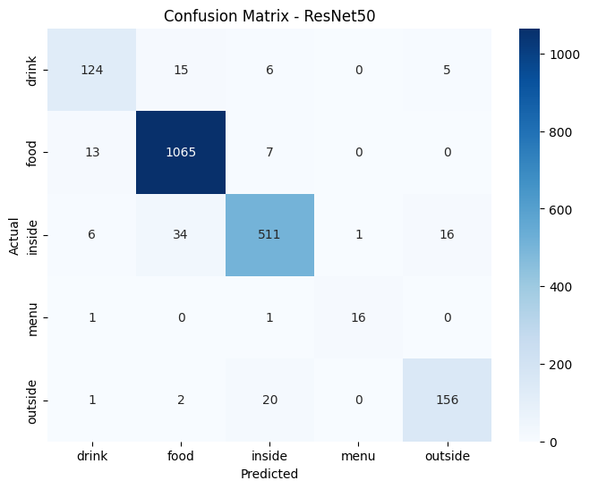

```
📋 Classification Report:
              precision    recall  f1-score   support

       drink       0.86      0.83      0.84       150
        food       0.95      0.98      0.97      1085
      inside       0.94      0.90      0.92       568
        menu       0.94      0.89      0.91        18
     outside       0.88      0.87      0.88       179

    accuracy                           0.94      2000
   macro avg       0.91      0.89      0.90      2000
weighted avg       0.94      0.94      0.94      2000


📊 Model Performance Summary:
                                   Metric   Score
0                                Accuracy  0.9360
1                       Balanced Accuracy  0.8937
2                                Log Loss  0.1860
3  Matthews Correlation Coefficient (MCC)  0.8948
4                     Cohen’s Kappa Score  0.8945
5                            Hamming Loss  0.0640
6                           Jaccard Score  0.8267
7                      Macro-Averaged AUC  0.9925
```

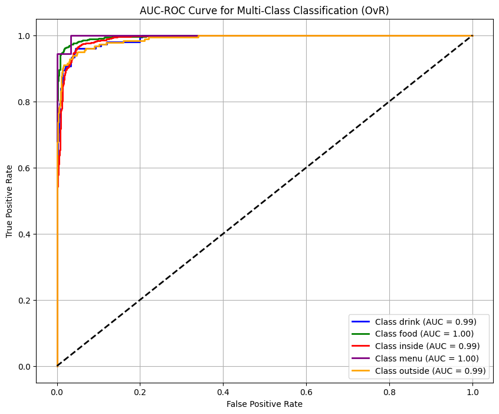

```python
cm = confusion_matrix(y_test_encoded, y_pred_classes_resnet)
plt.figure(figsize=(8, 6))
sns.heatmap(cm, annot=True, fmt='d', cmap='Blues',
            xticklabels=label_encoder.classes_,
            yticklabels=label_encoder.classes_)
plt.xlabel('Predicted')
plt.ylabel('Actual')
plt.title('Confusion Matrix - ResNet50')
plt.show()

accuracy = accuracy_score(y_test_encoded, y_pred_classes_resnet)
balanced_acc = balanced_accuracy_score(y_test_encoded, y_pred_classes_resnet)
logloss = log_loss(y_test_encoded, y_probs_resnet)
mcc = matthews_corrcoef(y_test_encoded, y_pred_classes_resnet)
kappa = cohen_kappa_score(y_test_encoded, y_pred_classes_resnet)
hamming = hamming_loss(y_test_encoded, y_pred_classes_resnet)


try:
    auc_score = roc_auc_score(y_test_encoded, y_probs_resnet, average='macro', multi_class='ovr')
except ValueError as e:
    auc_score = None
    print(f"❌ AUC could not be computed: {e}")


jaccard = jaccard_score(y_test_encoded, y_pred_classes_resnet, average='macro')


report = classification_report(y_test_encoded, y_pred_classes_resnet, target_names=label_encoder.classes_)
print("\n📋 Classification Report:")
print(report)


metrics_summary = {
    'Metric': [
        'Accuracy',
        'Balanced Accuracy',
        'Log Loss',
        'Matthews Correlation Coefficient (MCC)',
        'Cohen’s Kappa Score',
        'Hamming Loss',
        'Jaccard Score',
        'Macro-Averaged AUC'
    ],
    'Score': [
        f"{accuracy:.4f}",
        f"{balanced_acc:.4f}",
        f"{logloss:.4f}",
        f"{mcc:.4f}",
        f"{kappa:.4f}",
        f"{hamming:.4f}",
        f"{jaccard:.4f}",
        f"{auc_score:.4f}" if auc_score is not None else "N/A"
    ]
}

# Convert to DataFrame
summary_df = pd.DataFrame(metrics_summary)

# Display the summary
print("\n📊 Model Performance Summary:")
print(summary_df)


# Binarize the labels for multi-class ROC
y_test_binarized = label_binarize(y_test_encoded, classes=np.unique(y_test_encoded))
n_classes = y_test_binarized.shape[1]

# Colors for different classes
colors = cycle(['blue', 'green', 'red', 'purple', 'orange'])

# Plot ROC curve for each class
plt.figure(figsize=(10, 8))

for i, color in zip(range(n_classes), colors):
    fpr, tpr, _ = roc_curve(y_test_binarized[:, i], y_probs_resnet[:, i])
    auc_class = roc_auc_score(y_test_binarized[:, i], y_probs_resnet[:, i])
    plt.plot(fpr, tpr, color=color, lw=2,
             label=f"Class {label_encoder.classes_[i]} (AUC = {auc_class:.2f})")

# Plot random chance line
plt.plot([0, 1], [0, 1], 'k--', lw=2)

# Plot formatting
plt.xlabel('False Positive Rate')
plt.ylabel('True Positive Rate')
plt.title('AUC-ROC Curve for Multi-Class Classification (OvR)')
plt.legend(loc='lower right')
plt.grid(True)
plt.show()
```